# essai_avec_K=5

# Question 3

Ayant un jeu de données assez restreint, les **kmeans** sont utiles mais la CAH est encore faisable.  
Dans notre cas, la méthode des kmeans permet une convergence plus rapide. Nous savons d’ores et déjà que nous allons apporter notre aide au Nigéria en priorité. Nous souhaitons aider d’autres pays, c’est pourquoi nous avons sélectionné le deuxième cluster (dont on a parlé ci-dessus). Or, ce deuxième groupe contient 47 pays. Puisque notre budget est limité, nous allons réaliser une deuxième CAH pour le répartir le plus efficacement possible.

On souhaite donc récupérer les pays correspondant à ce deuxième cluster.  
Puisque la méthode des kmeans nous donne des numéros de groupe variable à chaque éxecution du programme, nous devons récupérer le bon groupe correspondant aux pays nécessiteux.  
On se base sur un pays étant dans le groupe des défavorisés et on récupère tous les autres du même groupe. On utilise le Benin comme référence pour accéder aux autres pays du même groupe (défavorisés)

```r
df_donnees_sc <- as.data.frame(donnees.sc)
# On récupère le numéro du groupe du Bénin :
num_grp <- df_donnees_sc$gpe.kmeans[rownames(df_donnees_sc)=="Benin"]
cat("Le numéro du groupe du bénin est",num_grp)
```

```
## Le numéro du groupe du bénin est 5
```

```r
# On récupère les données associées à ce groupe :
donnees.sc_defav <- df_donnees_sc[df_donnees_sc$gpe.kmeans==num_grp,]
donnees.sc_defav <- donnees.sc_defav[,-10] # on retire la colonne correspondant au groupe
```

## On réalise maintenant une deuxième CAH :

```r
D2 <- dist(donnees.sc_defav,method="euclidean")^2
```

Méthode CAH avec le saut minimal (single linkage) :

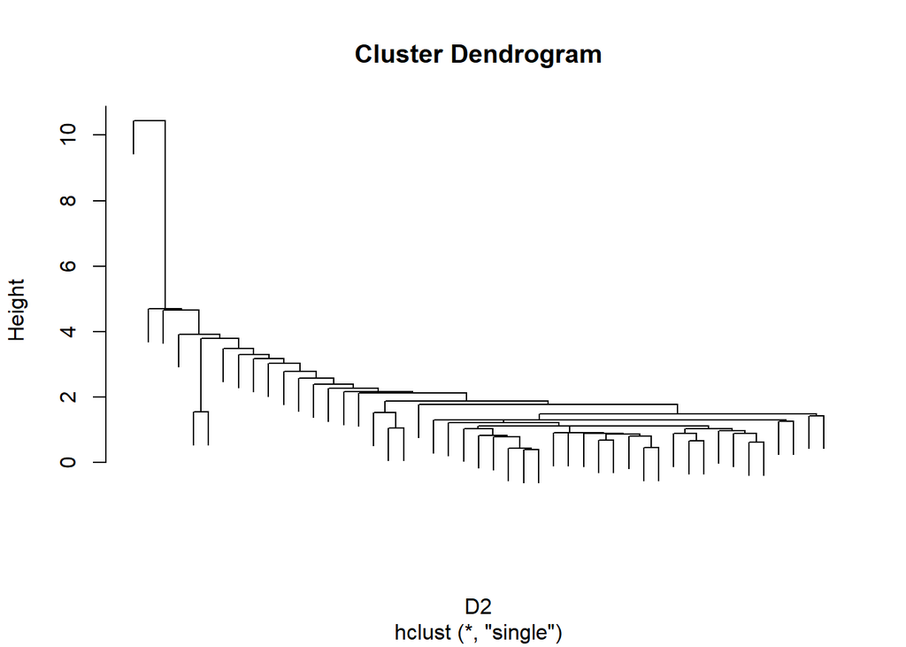

```r
CAH_min2 <- hclust(d= D2,method="single")
plot(CAH_min2, labels = FALSE)
```

Ce premier dendrogramme n’est pas très explicite et ne nous permet pas de faire un choix de partition clair.

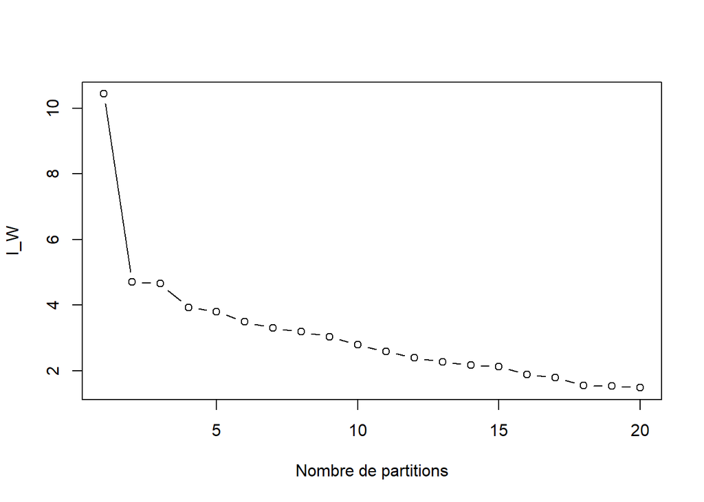

```r
plot(rev(CAH_min2$height)[1:20],type="b",xlab="Nombre de partitions",ylab="I_W")
```

Cependant, le tracé de la pertie d’inertie nous suggère de choisir une partition en 2 ou 3 groupes.

Méthode CAH avec le saut maximal :

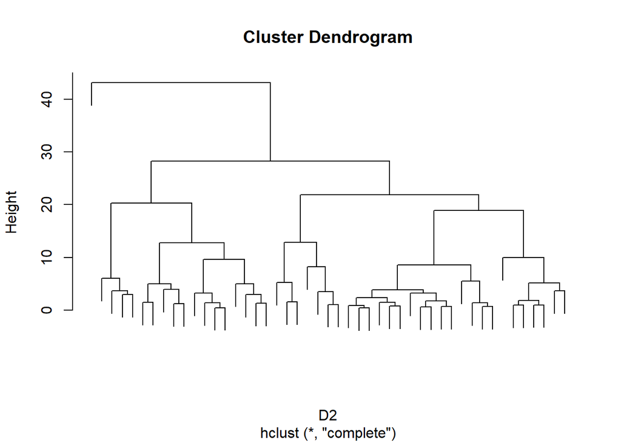

```r
CAH_max2 <- hclust(d= D2,method="complete")
plot(CAH_max2, labels = FALSE)
```

En analysant ce dendrogramme, nous pouvons distinguer 3 groupes de pays (un à droite, un au milieu et un à gauche).

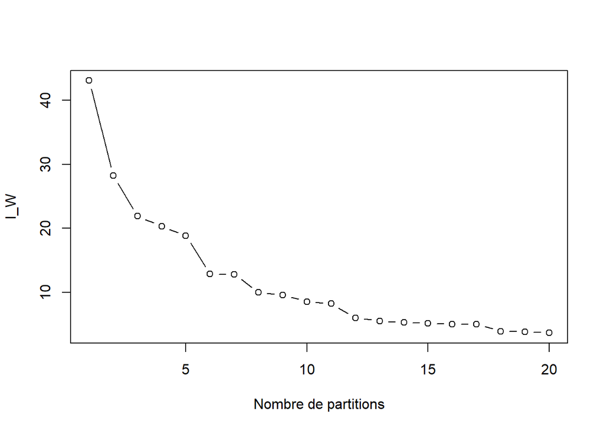

```r
plot(rev(CAH_max2$height)[1:20],type="b",xlab="Nombre de partitions",ylab="I_W")
```

Le graphique ci-dessus n’est pas très concluant quant à l’hypothèse de partition en deux groupes. Nous nous posons la question d’une éventuelle partition en 3 groupes de pays en observant les sauts d’inertie intra-classes.

CAH avec la distance de Ward :

Enfin, avec la distance de ward, on obtient les résultats suivants :

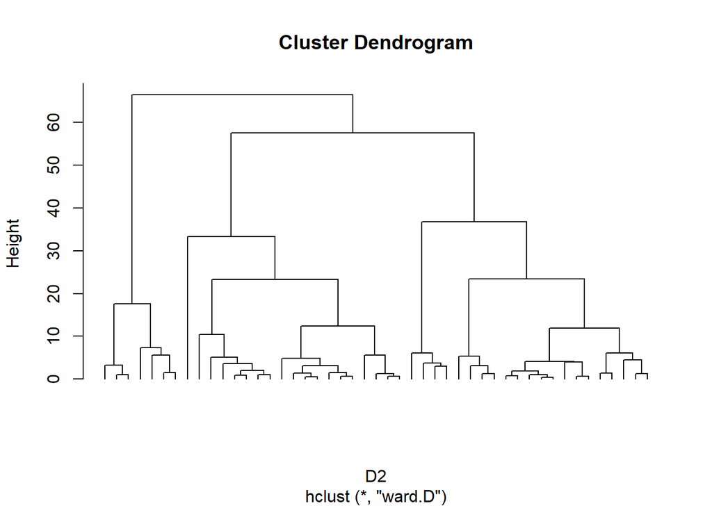

```r
CAH_ward2 <- hclust( d = D2,method="ward.D")
plot(CAH_ward2,hang=-1,labels=FALSE)
```

Le dendrogramme nous permet aussi de supposer l’existence de 3 groupes de pays.

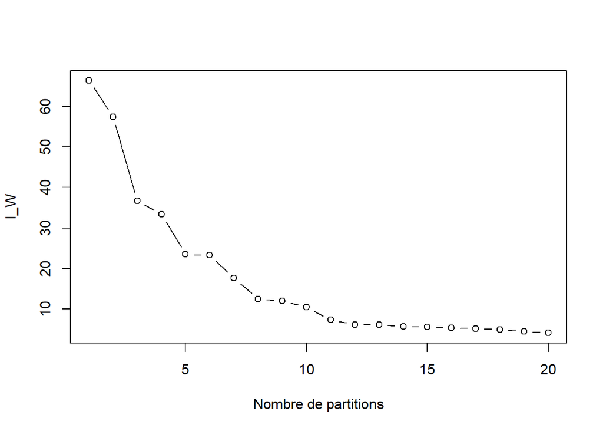

```r
plot(rev(CAH_ward2$height)[1:20],type="b",xlab="Nombre de partitions",ylab="I_W")
```

En conclusion, nous avons décidé de chosisir une partition en 3 groupes afin de diviser au mieux notre budget et de se focaliser sur les pays les plus nécessiteux.

Critère automatique à partir du package ‘NbClust’ :

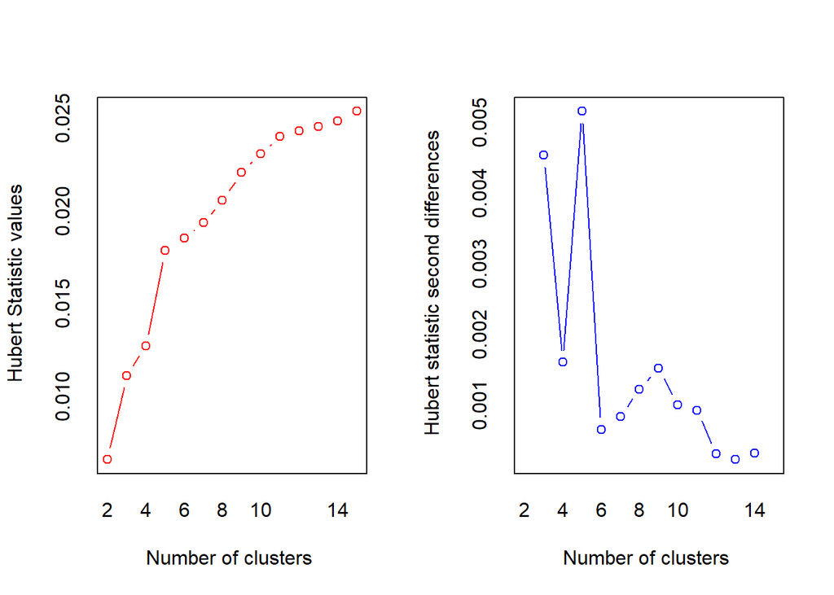

```
## *** : The Hubert index is a graphical method of determining the number of clusters.
##                 In the plot of Hubert index, we seek a significant knee that corresponds to a
##                 significant increase of the value of the measure i.e the significant peak in Hubert
##                 index second differences plot.
##
```

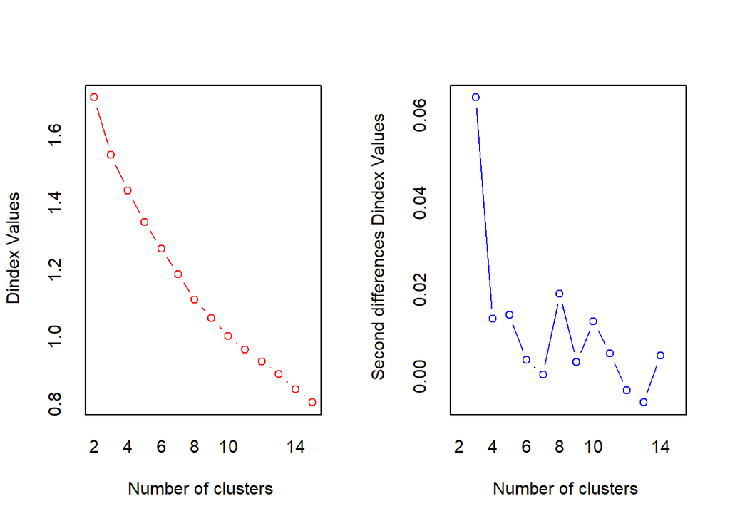

```
## *** : The D index is a graphical method of determining the number of clusters.
##                 In the plot of D index, we seek a significant knee (the significant peak in Dindex
##                 second differences plot) that corresponds to a significant increase of the value of
##                 the measure.
##
## * Among all indices:
## * 3 proposed 2 as the best number of clusters
## * 6 proposed 3 as the best number of clusters
## * 3 proposed 4 as the best number of clusters
## * 2 proposed 5 as the best number of clusters
## * 3 proposed 8 as the best number of clusters
## * 1 proposed 10 as the best number of clusters
## * 5 proposed 15 as the best number of clusters
##
##                    ***** Conclusion *****
##
## * According to the majority rule, the best number of clusters is  3
##
##
```

[output not shown]

[output cut: 56 more lines]

[output not shown]

```r
NbClust(donnees.sc_defav,min.nc = 2,max.nc = 15,method="ward.D",index="all")
```